# Milestone 1

```python
import pandas as pd
import matplotlib.pyplot as plt
import numpy as np
import seaborn as sns
from math import sin, cos,pi
from pandas_profiling import ProfileReport
import scipy.stats as stats
from sklearn.preprocessing import PowerTransformer
from sklearn.manifold import TSNE
from sklearn.decomposition import PCA
from sklearn.discriminant_analysis import LinearDiscriminantAnalysis
```

## Analiza danych

```python
data_raw = pd.read_csv("online_shoppers_intention.csv").drop("Revenue", axis=1)
display(data_raw)
display(data_raw.describe())
```

|  | Administrative | Administrative_Duration | Informational | Informational_Duration | ProductRelated | ProductRelated_Duration | BounceRates | ExitRates | PageValues | SpecialDay | Month | OperatingSystems | Browser | Region | TrafficType | VisitorType | Weekend |
| --- | --- | --- | --- | --- | --- | --- | --- | --- | --- | --- | --- | --- | --- | --- | --- | --- | --- |
| 0 | 0 | 0.0 | 0 | 0.0 | 1 | 0.000000 | 0.200000 | 0.200000 | 0.000000 | 0.0 | Feb | 1 | 1 | 1 | 1 | Returning_Visitor | False |
| 1 | 0 | 0.0 | 0 | 0.0 | 2 | 64.000000 | 0.000000 | 0.100000 | 0.000000 | 0.0 | Feb | 2 | 2 | 1 | 2 | Returning_Visitor | False |
| 2 | 0 | 0.0 | 0 | 0.0 | 1 | 0.000000 | 0.200000 | 0.200000 | 0.000000 | 0.0 | Feb | 4 | 1 | 9 | 3 | Returning_Visitor | False |
| 3 | 0 | 0.0 | 0 | 0.0 | 2 | 2.666667 | 0.050000 | 0.140000 | 0.000000 | 0.0 | Feb | 3 | 2 | 2 | 4 | Returning_Visitor | False |
| 4 | 0 | 0.0 | 0 | 0.0 | 10 | 627.500000 | 0.020000 | 0.050000 | 0.000000 | 0.0 | Feb | 3 | 3 | 1 | 4 | Returning_Visitor | True |
| ... | ... | ... | ... | ... | ... | ... | ... | ... | ... | ... | ... | ... | ... | ... | ... | ... | ... |
| 12325 | 3 | 145.0 | 0 | 0.0 | 53 | 1783.791667 | 0.007143 | 0.029031 | 12.241717 | 0.0 | Dec | 4 | 6 | 1 | 1 | Returning_Visitor | True |
| 12326 | 0 | 0.0 | 0 | 0.0 | 5 | 465.750000 | 0.000000 | 0.021333 | 0.000000 | 0.0 | Nov | 3 | 2 | 1 | 8 | Returning_Visitor | True |
| 12327 | 0 | 0.0 | 0 | 0.0 | 6 | 184.250000 | 0.083333 | 0.086667 | 0.000000 | 0.0 | Nov | 3 | 2 | 1 | 13 | Returning_Visitor | True |
| 12328 | 4 | 75.0 | 0 | 0.0 | 15 | 346.000000 | 0.000000 | 0.021053 | 0.000000 | 0.0 | Nov | 2 | 2 | 3 | 11 | Returning_Visitor | False |
| 12329 | 0 | 0.0 | 0 | 0.0 | 3 | 21.250000 | 0.000000 | 0.066667 | 0.000000 | 0.0 | Nov | 3 | 2 | 1 | 2 | New_Visitor | True |

12330 rows × 17 columns

|  | Administrative | Administrative_Duration | Informational | Informational_Duration | ProductRelated | ProductRelated_Duration | BounceRates | ExitRates | PageValues | SpecialDay | OperatingSystems | Browser | Region | TrafficType |
| --- | --- | --- | --- | --- | --- | --- | --- | --- | --- | --- | --- | --- | --- | --- |
| count | 12330.000000 | 12330.000000 | 12330.000000 | 12330.000000 | 12330.000000 | 12330.000000 | 12330.000000 | 12330.000000 | 12330.000000 | 12330.000000 | 12330.000000 | 12330.000000 | 12330.000000 | 12330.000000 |
| mean | 2.315166 | 80.818611 | 0.503569 | 34.472398 | 31.731468 | 1194.746220 | 0.022191 | 0.043073 | 5.889258 | 0.061427 | 2.124006 | 2.357097 | 3.147364 | 4.069586 |
| std | 3.321784 | 176.779107 | 1.270156 | 140.749294 | 44.475503 | 1913.669288 | 0.048488 | 0.048597 | 18.568437 | 0.198917 | 0.911325 | 1.717277 | 2.401591 | 4.025169 |
| min | 0.000000 | 0.000000 | 0.000000 | 0.000000 | 0.000000 | 0.000000 | 0.000000 | 0.000000 | 0.000000 | 0.000000 | 1.000000 | 1.000000 | 1.000000 | 1.000000 |
| 25% | 0.000000 | 0.000000 | 0.000000 | 0.000000 | 7.000000 | 184.137500 | 0.000000 | 0.014286 | 0.000000 | 0.000000 | 2.000000 | 2.000000 | 1.000000 | 2.000000 |
| 50% | 1.000000 | 7.500000 | 0.000000 | 0.000000 | 18.000000 | 598.936905 | 0.003112 | 0.025156 | 0.000000 | 0.000000 | 2.000000 | 2.000000 | 3.000000 | 2.000000 |
| 75% | 4.000000 | 93.256250 | 0.000000 | 0.000000 | 38.000000 | 1464.157214 | 0.016813 | 0.050000 | 0.000000 | 0.000000 | 3.000000 | 2.000000 | 4.000000 | 4.000000 |
| max | 27.000000 | 3398.750000 | 24.000000 | 2549.375000 | 705.000000 | 63973.522230 | 0.200000 | 0.200000 | 361.763742 | 1.000000 | 8.000000 | 13.000000 | 9.000000 | 20.000000 |

`Administrative` - This is the number of pages of this type (administrative) that the user visited.  
`Administrative_Duration` - This is the amount of time spent in this category of pages.  
`Informational` - This is the number of pages of this type (informational) that the user visited.  
`Informational_Duration` - This is the amount of time spent in this category of pages.  
`ProductRelated` - This is the number of pages of this type (product related) that the user visited.  
`ProductRelated_Duration` - This is the amount of time spent in this category of pages.  
`BounceRates` - The percentage of visitors who enter the website through that page and exit without triggering any additional tasks.  
`ExitRates` - The percentage of pageviews on the website that end at that specific page.  
`PageValues` - The average value of the page averaged over the value of the target page and/or the completion of an eCommerce transaction.  
`SpecialDay` - This value represents the closeness of the browsing date to special days or holidays (eg Mother's Day or Valentine's day) in which the transaction is more likely to be finalized.  
`Month` - Contains the month the pageview occurred, in string form.  
`OperatingSystems` - An integer value representing the operating system that the user was on when viewing the page.  
`Browser` - An integer value representing the browser that the user was using to view the page.  
`Region` - An integer value representing which region the user is located in.  
`TrafficType` - An integer value representing what type of traffic the user is categorized into.  
`VisitorType` - A string representing whether a visitor is New Visitor, Returning Visitor, or Other.  
`Weekend` - A boolean representing whether the session is on a weekend.

```python
report = ProfileReport(data_raw)
report.to_file("automated_EDA.html")
```

Mamy tutaj trzy kolumny nienumeryczne - `Weekend`, `VisitorType` i `Month`.

`Weekend` jest po prostu zmienną logiczną i pokazuje kiedy użytkownik korzystał z serwisu. Tutaj widać większa ilość w ciągu tygodnia niż w weekend, nawet po uwzględnieniu proporcjonalnej długości. Tą kolumnę można łatwo przekonwertować na numeryczną.

Zmienna `VisitorType` przyjmuje trzy różne wartości - `Returning_Visitor`, `New_Visitor` i `Other`. Warto tutaj zaznaczyć że wartości `Returning_Visitor` jest około 6 razy więcej niż `New_Visitor`, a tych jest około 20 razy więcej niż `Other`. Można ją zatem zakodować one-hot encoding dwoma kolumnami.

Najciekawszą z tych kolumn jest kolumna `Month`, ponieważ jest ona cykliczną wartością czasu. W niej widzimy bardzo nierówny rozkład danych - 50% wszystkich wartości to jedynie dwa miesiące: maj i listopad. Aby ją zakodować użyjemy dwóch kolumn, `sin(2pi * month/12)` i `cos(2pi * month/12)`, gdzie `month` to numer miesiąca w roku. W ten sposób zachowujemy informacje o cykliczności tej zmiennej.

Kolejnym utrudnieniem w tym zbiorze danych są kolumny `OperatingSystems`, `Browser`, `Region` i `TrafficType`. Mimo że wyglądają one na zmienne numeryczne, w rzeczywistości są zmiennymi kategorycznymi (rodzaj systemu operacyjnego, rodzaj przeglądarki internetowej, region użytkownika i rodzaj połączenia). Zarówno w `OperatingSystems` jak i w `Browser` widzimy że większość użytkowników korzysta z 3 systemów/2 przeglądarek. W `Region` też widzimy jedną wartość zdecydowanie większą niż pozostałe. Niestety, opisy datasetu nie precyzją co te wartości oznaczają. Nie wiemy zatem czy kolejność w jakiej zostały ułożone niesie za sobą jakąś informację, czy jest wyłącznie szumem. Dlatego aby zminimalizować ryzyko bazowania na błędnych danych postanowiliśmy zakodować każdą z nich za pomocą one-hot encoding.

```python
# One-hot encoding
data = pd.get_dummies(data_raw, columns=['OperatingSystems', 'Browser', 'Region', 'TrafficType', 'VisitorType'], drop_first=1)

# Weekend
data["Weekend"] = data["Weekend"].astype(int)

# Month encoding
months = ['Jan', 'Feb', 'Mar', 'Apr','May', 'June',
          'Jul', 'Aug', 'Sep', 'Oct', 'Nov','Dec']
data['Month'] = data['Month'].transform(lambda month: months.index(month))
data['MonthSin'] = data['Month'].transform(
    lambda monthIdx: sin(2*pi * monthIdx/12))
data['MonthCos'] = data['Month'].transform(
    lambda monthIdx: cos(2*pi * monthIdx/12))

display(data)
```

|  | Administrative | Administrative_Duration | Informational | Informational_Duration | ProductRelated | ProductRelated_Duration | BounceRates | ExitRates | PageValues | SpecialDay | ... | TrafficType_15 | TrafficType_16 | TrafficType_17 | TrafficType_18 | TrafficType_19 | TrafficType_20 | VisitorType_Other | VisitorType_Returning_Visitor | MonthSin | MonthCos |
| --- | --- | --- | --- | --- | --- | --- | --- | --- | --- | --- | --- | --- | --- | --- | --- | --- | --- | --- | --- | --- | --- |
| 0 | 0 | 0.0 | 0 | 0.0 | 1 | 0.000000 | 0.200000 | 0.200000 | 0.000000 | 0.0 | ... | 0 | 0 | 0 | 0 | 0 | 0 | 0 | 1 | 0.500000 | 0.866025 |
| 1 | 0 | 0.0 | 0 | 0.0 | 2 | 64.000000 | 0.000000 | 0.100000 | 0.000000 | 0.0 | ... | 0 | 0 | 0 | 0 | 0 | 0 | 0 | 1 | 0.500000 | 0.866025 |
| 2 | 0 | 0.0 | 0 | 0.0 | 1 | 0.000000 | 0.200000 | 0.200000 | 0.000000 | 0.0 | ... | 0 | 0 | 0 | 0 | 0 | 0 | 0 | 1 | 0.500000 | 0.866025 |
| 3 | 0 | 0.0 | 0 | 0.0 | 2 | 2.666667 | 0.050000 | 0.140000 | 0.000000 | 0.0 | ... | 0 | 0 | 0 | 0 | 0 | 0 | 0 | 1 | 0.500000 | 0.866025 |
| 4 | 0 | 0.0 | 0 | 0.0 | 10 | 627.500000 | 0.020000 | 0.050000 | 0.000000 | 0.0 | ... | 0 | 0 | 0 | 0 | 0 | 0 | 0 | 1 | 0.500000 | 0.866025 |
| ... | ... | ... | ... | ... | ... | ... | ... | ... | ... | ... | ... | ... | ... | ... | ... | ... | ... | ... | ... | ... | ... |
| 12325 | 3 | 145.0 | 0 | 0.0 | 53 | 1783.791667 | 0.007143 | 0.029031 | 12.241717 | 0.0 | ... | 0 | 0 | 0 | 0 | 0 | 0 | 0 | 1 | -0.500000 | 0.866025 |
| 12326 | 0 | 0.0 | 0 | 0.0 | 5 | 465.750000 | 0.000000 | 0.021333 | 0.000000 | 0.0 | ... | 0 | 0 | 0 | 0 | 0 | 0 | 0 | 1 | -0.866025 | 0.500000 |
| 12327 | 0 | 0.0 | 0 | 0.0 | 6 | 184.250000 | 0.083333 | 0.086667 | 0.000000 | 0.0 | ... | 0 | 0 | 0 | 0 | 0 | 0 | 0 | 1 | -0.866025 | 0.500000 |
| 12328 | 4 | 75.0 | 0 | 0.0 | 15 | 346.000000 | 0.000000 | 0.021053 | 0.000000 | 0.0 | ... | 0 | 0 | 0 | 0 | 0 | 0 | 0 | 1 | -0.866025 | 0.500000 |
| 12329 | 0 | 0.0 | 0 | 0.0 | 3 | 21.250000 | 0.000000 | 0.066667 | 0.000000 | 0.0 | ... | 0 | 0 | 0 | 0 | 0 | 0 | 0 | 0 | -0.866025 | 0.500000 |

12330 rows × 62 columns

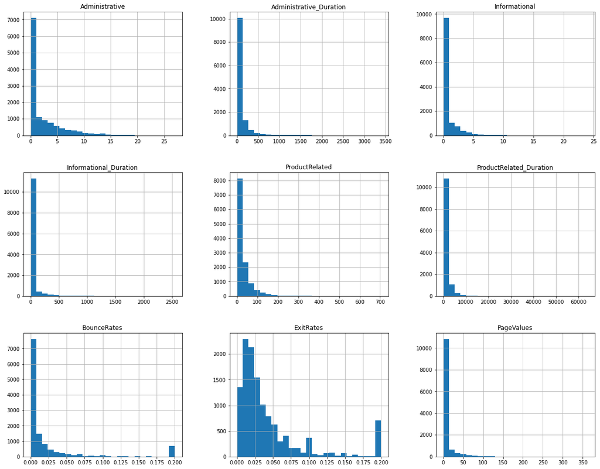

```python
columns = ["Administrative","Administrative_Duration","Informational","Informational_Duration","ProductRelated","ProductRelated_Duration","BounceRates","ExitRates","PageValues"]
data[columns].hist(figsize=(20,16), bins=25)
plt.show()
```

W wygenerowanym EDA widzimy że dużo zmiennych jest prawoskośnych z bardzo długim ogonem. Dla `Administrative_Duration`, `Informational_Duration` i `ProductRelated_Duration` można to łatwo wytłumaczyć - w każdej minucie korzystania ze strony użytkownik ma jakieś prawdopodobieństwo że z niej wyjdzie.

Chcemy aby otrzymane klastry były jak najlepszej jakości, dlatego te zmienne powinny być przkeształcone. Do tego wybraliśmy transformację Yeo-Johnson, jako iż ma ona bardzo dobre własności normalizujące. Parametr tej transformacji dobierzemy automatycznie, za pomocą funkcji z sklearn. Jeżeli chcielibyśmy dodać nowe wiersze do klasteryzacji to możemy odzyskać wartości tych przekształceń.

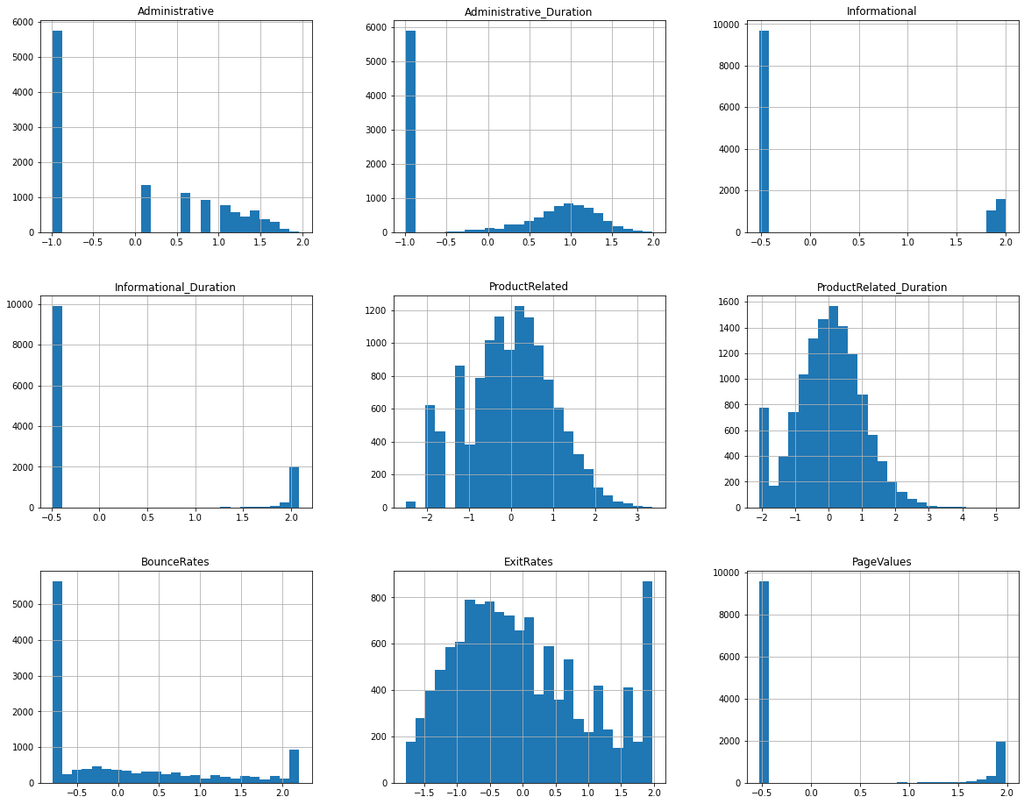

```python
pt = PowerTransformer()
pt.fit(data[columns])
data[columns] = pt.transform(data[columns])

data[columns].hist(figsize=(20,16), bins=25)
plt.show()
```

Widzimy że uzyskane rozkłady dużo bardziej przypominają rozkład normalny. Ciągle widać jednak wpływ dużej ilości zer w niektórych z tych zmiennych.

Dane należy jeszcze znormalizować do dalszego użytku.

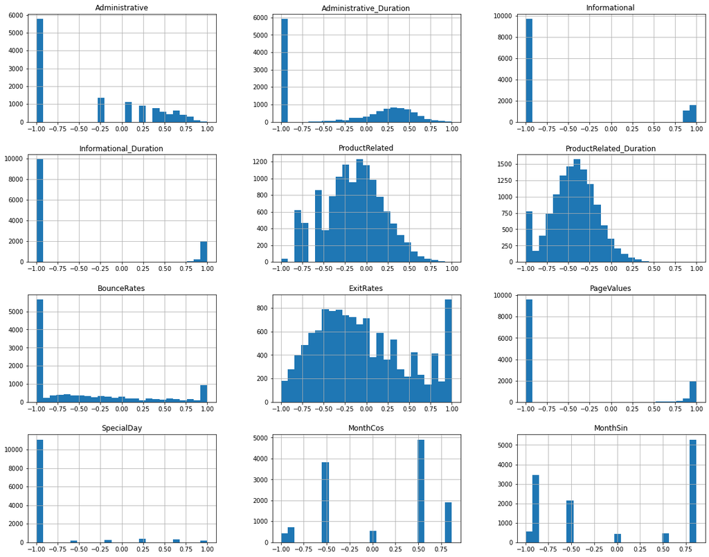

```python
for col in [*columns, "SpecialDay"]:
    data[col] = ((data[col]-data[col].min())/(data[col].max()-data[col].min())*2-1)

data[[*columns, "SpecialDay", "MonthCos", "MonthSin"]].hist(figsize=(20,16), bins=25)
plt.show()
```

## Wizualizacja zbioru

```python
# Helper functions to display a grid of plots
plotGrid_length = 0
plotGrid_height = 0
plotGrid_count = 0
def initPlotGrid(rowLength, totalPlots, showTicks = False):
    global plotGrid_length, plotGrid_count, plotGrid_height
    plotGrid_length = rowLength
    plotGrid_height = (totalPlots // rowLength) + 1 if totalPlots % rowLength > 0 else totalPlots // rowLength
    plotGrid_count = 0

    plt.rcParams['figure.figsize'] = [30, 30/plotGrid_length*plotGrid_height*0.8]
    if(not showTicks):
        plt.rcParams['axes.grid'] = False
        plt.rcParams['xtick.labelsize'] = False
        plt.rcParams['ytick.labelsize'] = False
        plt.rcParams['xtick.top'] = False
        plt.rcParams['xtick.bottom'] = False
        plt.rcParams['ytick.left'] = False
        plt.rcParams['ytick.right'] = False

def addToGrid():
    global plotGrid_length, plotGrid_count
    plt.subplot(plotGrid_height, plotGrid_length, plotGrid_count+1)
    plotGrid_count += 1

def finalizePlotGrid():
    plt.show()
    plt.style.use('default')
```

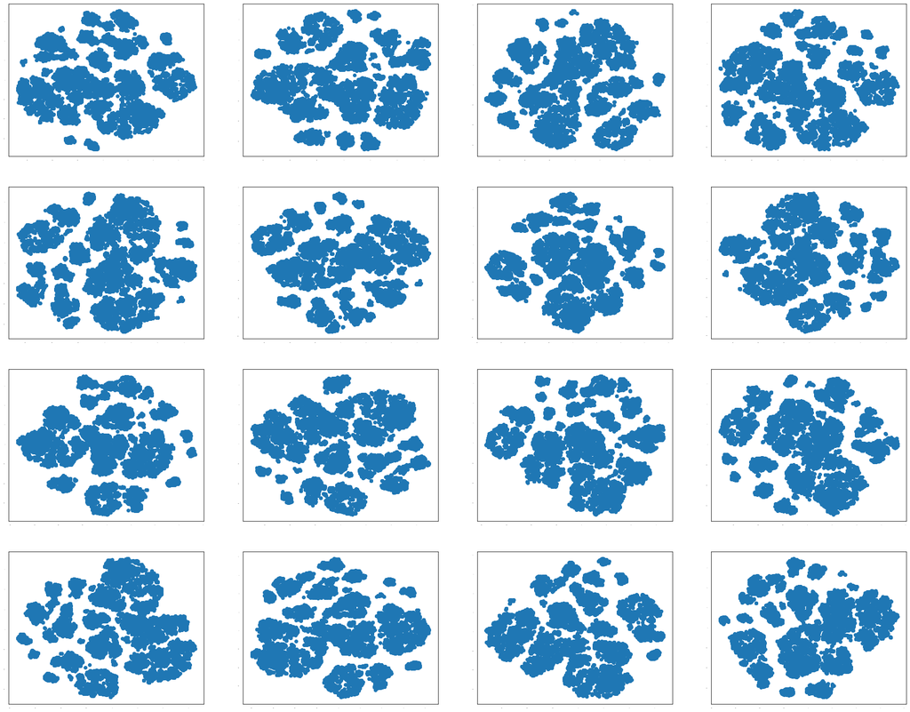

```python
initPlotGrid(4, 16)
for i in range(16):
    addToGrid()
    tsne = TSNE().fit_transform(data)
    plt.scatter(tsne[:,0], tsne[:,1])

finalizePlotGrid()
```

Jako że wizualizacja t-SNE bazuje na elementach losowych, postanowiliśmy przedstawić 16 różnych iteracji tego algorytmy, aby uzyskać bardziej realny obraz danych.

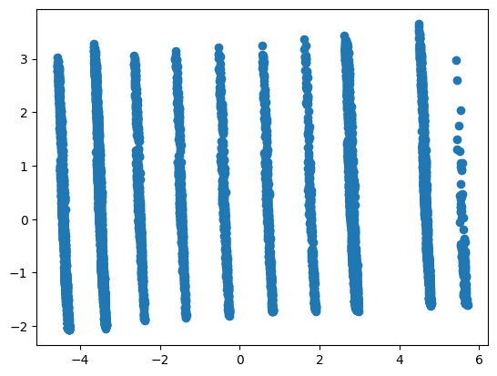

```python
pca = PCA(n_components=2).fit_transform(data)
plt.scatter(pca[:,0], pca[:,1])
plt.show()
```

Wizualizacja za pomocą metody PCA dała bardziej interesujące wyniki. Od razu uwidacznia się 10 "klas", jednak użyteczność tego podziału jest wątpliwa. Należałoby by dokładniej zbadać zachowanie danych wewnątrz tych "klas".

Stawia to pod znakiem zapytania użyteczność metody PCA, jednak innym możliwym powodem takiego podziału jest wykorzystanie one-hot encodingu przy przygotowywaniu danych. Jest to operacja znacząco zwiększająca wymiarowość danych i bezpośrednio wpływająca na jakość uzyskiwanych klastrów. W dalszych pracach nad projektem należałoby wrócić do tej kwestii, przeanalizować wpływ one-hot encoding i znaleźć jak najbardziej optymalne rozwiązanie problemu ze zmiennymi kategorycznymi.